# Time and date information

Anthony Davidson

# Sorting out times and datas

This is a nasty task in any project however it is important to understand how much data we have and how that might be changing as we are developing and publishing the results. To check this we can recreate the date folder and run a set of functions over this until we get a useable variable.

## Looks like?

Data stored as list of csvs in rds file called raw_rds

[figure not shown]

## nice plot

```r
# Library
library(dygraphs)
library(xts)          # To make the convertion data-frame / xts format

  res <- res %>%
          filter(contact == "Close")
# Create data
# data <- data.frame(
#   time=res$date[10:57], to=Sys.Date(), by=1 ),
#   value=res$nsites
# )

# Double check time is at the date format
# str(data$time)
times <- c("9:06am", "4:42 PM", "3:05 PM", "12:00 PM", "3:38 AM")

print(as.POSIXct(dat$Arrival.Time, format='%I:%M %p'))

lubridate::hm(as.character(dat$Arrival.Time))

# end aim
lubridate::ymd_hms("2016-07-08 12:34:56")

# Switch to XTS format
# data <- xts(x = res$nsites[10:57], order.by = as.Date(lubridate::dmy(res$date[10:57])))

# Default = line plot --> See chart #316

# # Add points
# p <- dygraph(data) %>%
#   dyOptions( drawPoints = TRUE, pointSize = 4 ,)
#
# p
#
# # save the widget
# library(htmlwidgets)
# saveWidget(p, file=paste0( getwd(), "/HtmlWidget/dygraphs317-1.html"))
```

# Summarised outcome

## “New” Exposure sites per update (since outbreak)

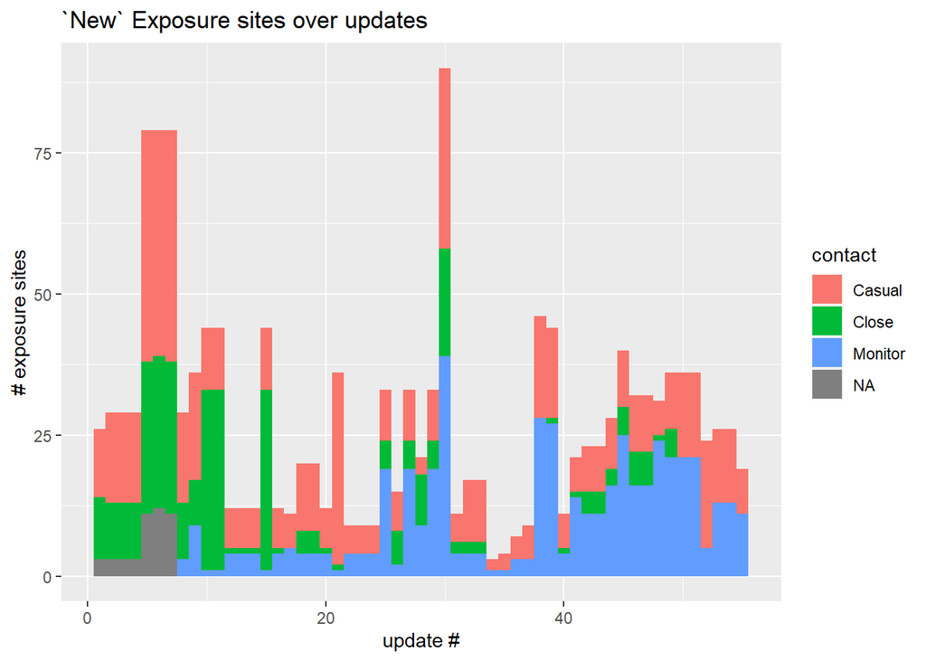

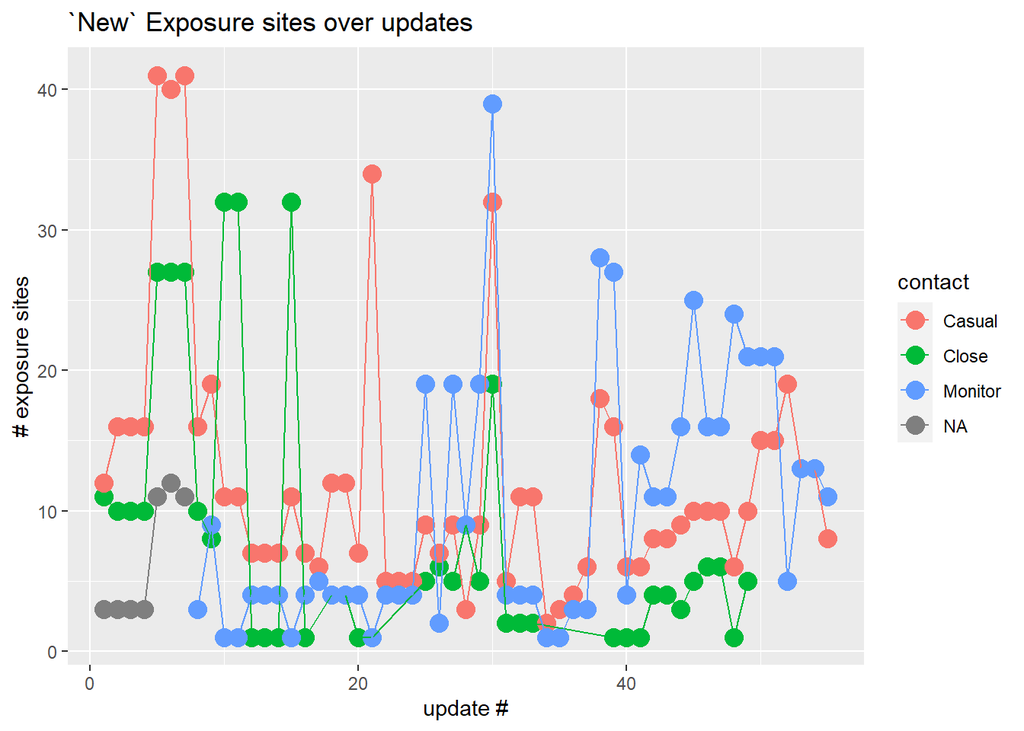

TIme

```r
  # dat$caseS <- as.difftime(as.Date(dat$Arrival.Time), as.Date(dat$Departure.Time))
dat <- read.csv("https://raw.githubusercontent.com/green-striped-gecko/covid_canberra/main/data/last.csv")
# Aggregate method


dat$Departure.Time <- format(strptime(dat$Departure.Time, "%I:%M %p"),format="%H:%M:%S")
dat$Arrival.Time <- format(strptime(dat$Arrival.Time, "%I:%M %p"),format="%H:%M:%S")

str(dat$Arrival.Time)
```

```
##  chr [1:327] "12:20:00" "12:50:00" "15:15:00" "10:30:00" "11:20:00" ...
```

```r
# dat$Arrival.Time - as.numeric(as.character(dat$Departure.Time))

as.difftime(dat$Arrival.Time, dat$Departure.Time)
```

[output not shown]

## September

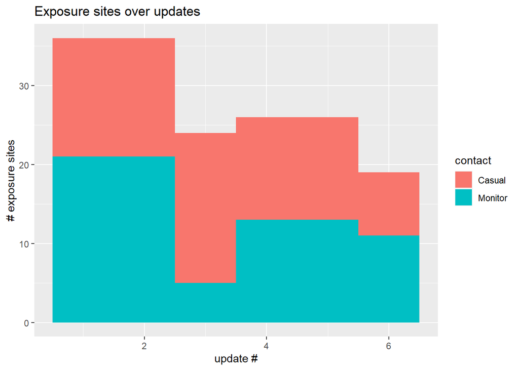

## Days in outbreak and contact counts (only new entries)

Hot days in current dataset (only new entries)?

This information is for visual understanding only and may not represent the true risk or prevalence in the community or areas defined below.

We can take a dynamic snapshot of the hot spots by taking this curated dataset and running the following analysis:

```r
############function 2 ######################
##function to link all files into a list[[i]]
countsperupdate <- function(allfiles){

  allfiledat <- list() #<- list() MUST BE OUTSIDE

    for(i in 1:length(allfiles)) {
      tib <- read_csv(allfiles[i]) %>%
            dplyr::select(Contact, Date, Suburb, Status) #%>%
              # filter(Status == "New")

    allfiledat[[i]] <- as.data.frame(tib)
  } #end loop

  return(allfiledat)

} #end function

##setup list of data
allfiledat <- list()
#run function
allfiledat <- countsperupdate(allfiles = allfiles)

#write this as
for(i in 1:length(allfiles)){

  dd <- allfiledat[[i]]
  tt <- table(dd$Contact)

  if (length(tt)>10) {
  for (ii in 1:length(tt))
    {
    res[cc, 1] <- i
    res[cc,2] <- (substr(dd$Date[i], 1,10))
    res[cc,3] <- nrow(dd)
    res[cc,4] <- names(tt)[ii]
    res[cc,5] <- tt[ii]
    cc <- cc+1
    }
  }
}

glimpse(allfiledat)
```

```
## List of 6
##  $ :'data.frame':    225 obs. of  4 variables:
##   ..$ Contact: chr [1:225] "Casual" "Casual" "Monitor" "Casual" ...
##   ..$ Date   : chr [1:225] "30/08/2021 - Monday" "30/08/2021 - Monday" "30/08/2021 - Monday" "30/08/2021 - Monday" ...
##   ..$ Suburb : chr [1:225] "Charnwood" "Gungahlin" "Gungahlin" "Gungahlin" ...
##   ..$ Status : chr [1:225] NA "New" "New" "New" ...
##  $ :'data.frame':    225 obs. of  4 variables:
##   ..$ Contact: chr [1:225] "Casual" "Casual" "Monitor" "Casual" ...
##   ..$ Date   : chr [1:225] "30/08/2021 - Monday" "30/08/2021 - Monday" "30/08/2021 - Monday" "30/08/2021 - Monday" ...
##   ..$ Suburb : chr [1:225] "Charnwood" "Gungahlin" "Gungahlin" "Gungahlin" ...
##   ..$ Status : chr [1:225] NA "New" "New" "New" ...
##  $ :'data.frame':    231 obs. of  4 variables:
##   ..$ Contact: chr [1:231] "Monitor" "Monitor" "Casual" "Casual" ...
##   ..$ Date   : chr [1:231] "18/08/2021 - Wednesday" "19/08/2021 - Thursday" "22/08/2021 - Sunday" "23/08/2021 - Monday" ...
##   ..$ Suburb : chr [1:231] "O'Connor" "Wanniassa" "Amaroo" "Belconnen" ...
##   ..$ Status : chr [1:231] NA NA NA NA ...
##  $ :'data.frame':    242 obs. of  4 variables:
##   ..$ Contact: chr [1:242] "Monitor" "Casual" "Casual" "Monitor" ...
##   ..$ Date   : chr [1:242] "19/08/2021 - Thursday" "22/08/2021 - Sunday" "23/08/2021 - Monday" "24/08/2021 - Tuesday" ...
##   ..$ Suburb : chr [1:242] "Wanniassa" "Amaroo" "Belconnen" "Evatt" ...
##   ..$ Status : chr [1:242] NA NA NA NA ...
##  $ :'data.frame':    242 obs. of  4 variables:
##   ..$ Contact: chr [1:242] "Monitor" "Casual" "Casual" "Monitor" ...
##   ..$ Date   : chr [1:242] "19/08/2021 - Thursday" "22/08/2021 - Sunday" "23/08/2021 - Monday" "24/08/2021 - Tuesday" ...
##   ..$ Suburb : chr [1:242] "Wanniassa" "Amaroo" "Belconnen" "Evatt" ...
##   ..$ Status : chr [1:242] NA NA NA NA ...
##  $ :'data.frame':    238 obs. of  4 variables:
##   ..$ Contact: chr [1:238] "Monitor" "Monitor" "Monitor" "Monitor" ...
##   ..$ Date   : chr [1:238] "01/09/2021 - Wednesday" "01/09/2021 - Wednesday" "01/09/2021 - Wednesday" "01/09/2021 - Wednesday" ...
##   ..$ Suburb : chr [1:238] "Mawson" "Fyshwick" "Narrabundah" "Narrabundah" ...
##   ..$ Status : chr [1:238] "New" "New" "New" "New" ...
```

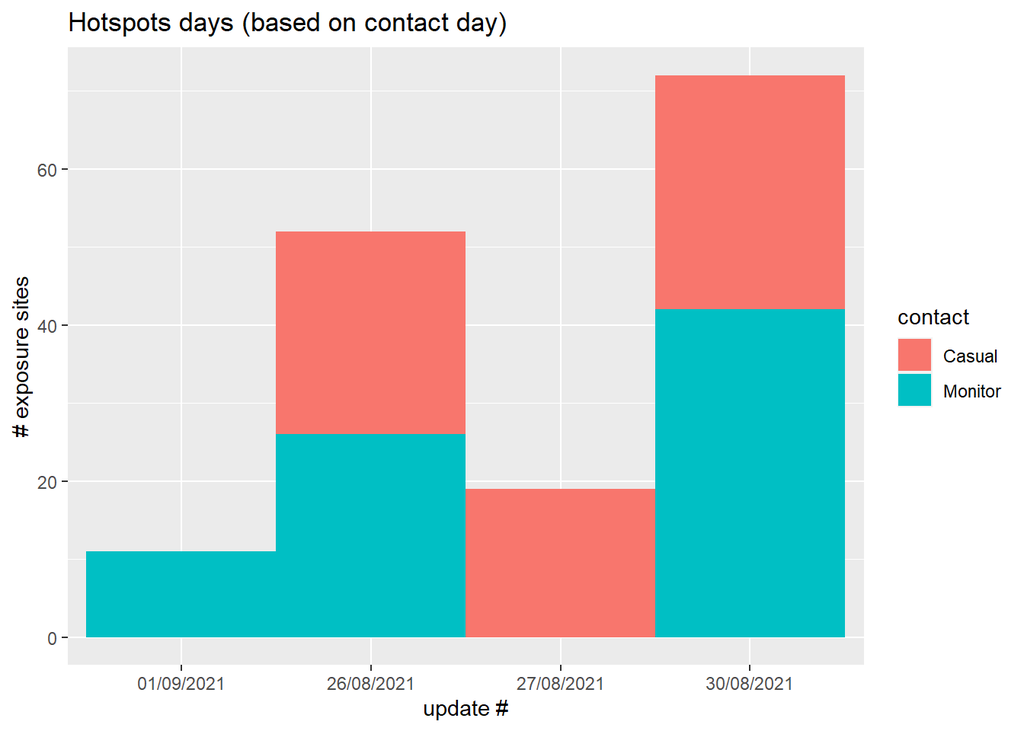

```r
# allfiledat

res1 <- filter(res,  nsites > 10)

res1 <- res1[!res1$contact=="Investigation information",]
res1 <- res1[!res1$contact=="Investigation location",]
res1$contact <- factor(res1$contact, levels=c("Close", "Casual","Monitor"))


res1 <- res1[order(res1$contact),]
cols <- c( "red", "yellow","blue")[as.numeric(res1$contact)]

ggplot(res1, aes(x=date,y=nsites))+geom_bar(stat="identity", position = "stack", width=1, aes(fill=contact))+
  xlab("update #")+
  ylab("# exposure sites")+
  ggtitle("Hotspots days (based on contact day)")
```

[figure not shown]

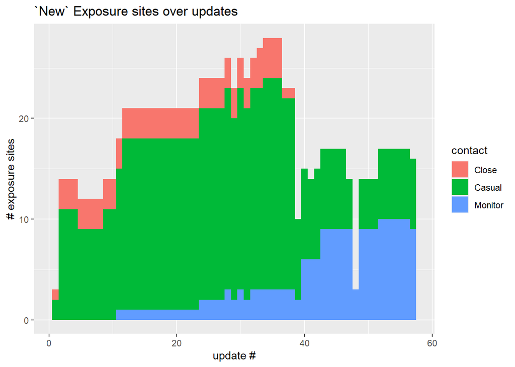

## Time is interesting

length of time: start and end time